# Overview

Dataset info

| Number of variables | 16 |
| --- | --- |
| Number of observations | 2051 |
| Missing cells | 674 (2.1%) |
| Duplicate rows | 0 (0.0%) |
| Total size in memory | 256.5 KiB |
| Average record size in memory | 128.1 B |

Variables types

| Numeric | 8 |
| --- | --- |
| Categorical | 6 |
| Boolean | 0 |
| Date | 0 |
| URL | 0 |
| Text (Unique) | 0 |
| Rejected | 2 |
| Unsupported | 0 |

Warnings

| `depth` is highly skewed (γ1 = -28.37020322) | Skewed |
| --- | --- |
| `depth` has 1726 (84.2%) zeros | Zeros |
| `id_no` is highly correlated with `date_long` (ρ = 0.9999959739) | Rejected |
| `latitude` has 24 (1.2%) zeros | Zeros |
| `longitude` has 24 (1.2%) zeros | Zeros |
| `magnitude_body` has 1217 (59.3%) zeros | Zeros |
| `magnitude_surface` has 1883 (91.8%) zeros | Zeros |
| `name` has a high cardinality: 1309 distinct values | Warning |
| `name` has 665 (32.4%) missing values | Missing |
| `region` has a high cardinality: 79 distinct values | Warning |
| `year` is highly correlated with `id_no` (ρ = 0.9999959812) | Rejected |
| `yield_lower` has 812 (39.6%) zeros | Zeros |
| `yield_upper` has 36 (1.8%) zeros | Zeros |

# Variables

country  
Categorical

| Distinct count | 7 |
| --- | --- |
| Unique (%) | 0.3% |
| Missing (%) | 0.0% |
| Missing (n) | 0 |

| USA | 1032 |
| --- | --- |
| USSR | 714 |
| FRANCE | 210 |
| Other values (4) | 95 |

Toggle details

**Common values**

| Value | Count | Frequency (%) |  |
| --- | --- | --- | --- |
| USA | 1032 | 50.3% |  |
| USSR | 714 | 34.8% |  |
| FRANCE | 210 | 10.2% |  |
| CHINA | 45 | 2.2% |  |
| UK | 45 | 2.2% |  |
| INDIA | 3 | 0.1% |  |
| PAKIST | 2 | 0.1% |  |

**Composition**

| Max length | 6 |
| --- | --- |
| Mean length | 3.683081424 |
| Min length | 2 |
| Contains chars | True |
| Contains digits | False |
| Contains spaces | False |
| Contains non-words | False |

date_long  
Numeric

| Distinct count | 1756 |
| --- | --- |
| Unique (%) | 85.6% |
| Missing (%) | 0.0% |
| Missing (n) | 0 |
| Infinite (%) | 0.0% |
| Infinite (n) | 0 |

| Mean | 19709735.64 |
| --- | --- |
| Minimum | 19450716 |
| Maximum | 19980530 |
| Zeros (%) | 0.0% |

[figure not shown]

Toggle details

**Statistics**

Quantile statistics

| Minimum | 19450716 |
| --- | --- |
| 5-th percentile | 19560523.5 |
| Q1 | 19621066 |
| Median | 19700501 |
| Q3 | 19790920 |
| 95-th percentile | 19880826.5 |
| Maximum | 19980530 |
| Range | 529814 |
| Interquartile range | 169854 |

Descriptive statistics

| Standard deviation | 103675.7084 |
| --- | --- |
| Coef of variation | 0.005260126786 |
| Kurtosis | -0.8312427352 |
| Mean | 19709735.64 |
| MAD | 87936.67656 |
| Skewness | 0.1676987827 |
| Sum | 4.042466779e+10 |
| Variance | 1.07486525e+10 |
| Memory size | 16.1 KiB |

**Histogram**

[figure not shown]

**Histogram with fixed size bins** (bins=50)

[figure not shown]

**Histogram with variable size bins** (bins=[19450716. 19450807. 19510127.5 19511124. 19520408. ... 19920924. 19950666. 19951174. 19980512. 19980530. ], ["bayesian blocks"](https://ui.adsabs.harvard.edu/abs/2013ApJ...764..167S/abstract) binning strategy used)

**Common values**

| Value | Count | Frequency (%) |  |
| --- | --- | --- | --- |
| 19830924 | 6 | 0.3% |  |
| 19581022 | 5 | 0.2% |  |
| 19621223 | 4 | 0.2% |  |
| 19841027 | 4 | 0.2% |  |
| 19611104 | 4 | 0.2% |  |
| 19780927 | 4 | 0.2% |  |
| 19581030 | 4 | 0.2% |  |
| 19621224 | 4 | 0.2% |  |
| 19621101 | 4 | 0.2% |  |
| 19821016 | 4 | 0.2% |  |
| Other values (1746) | 2008 | 97.9% |  |

**Extreme values**

Minimum 5 values

| Value | Count | Frequency (%) |  |
| --- | --- | --- | --- |
| 19450716 | 1 | < 0.1% |  |
| 19450805 | 1 | < 0.1% |  |
| 19450809 | 1 | < 0.1% |  |
| 19460630 | 1 | < 0.1% |  |
| 19460724 | 1 | < 0.1% |  |

Maximum 5 values

| Value | Count | Frequency (%) |  |
| --- | --- | --- | --- |
| 19980530 | 1 | < 0.1% |  |
| 19980528 | 1 | < 0.1% |  |
| 19980513 | 1 | < 0.1% |  |
| 19980511 | 1 | < 0.1% |  |
| 19960729 | 1 | < 0.1% |  |

depth  
Numeric

| Distinct count | 137 |
| --- | --- |
| Unique (%) | 6.7% |
| Missing (%) | 0.0% |
| Missing (n) | 0 |
| Infinite (%) | 0.0% |
| Infinite (n) | 0 |

| Mean | -0.489632862 |
| --- | --- |
| Minimum | -400 |
| Maximum | 1.451 |
| Zeros (%) | 84.2% |

[figure not shown]

Toggle details

**Statistics**

Quantile statistics

| Minimum | -400 |
| --- | --- |
| 5-th percentile | -0.001 |
| Q1 | 0 |
| Median | 0 |
| Q3 | 0 |
| 95-th percentile | 0.366 |
| Maximum | 1.451 |
| Range | 401.451 |
| Interquartile range | 0 |

Descriptive statistics

| Standard deviation | 10.96769872 |
| --- | --- |
| Coef of variation | -22.39984194 |
| Kurtosis | 925.8633987 |
| Mean | -0.489632862 |
| MAD | 1.029996113 |
| Skewness | -28.37020322 |
| Sum | -1004.237 |
| Variance | 120.2904152 |
| Memory size | 16.1 KiB |

**Histogram**

[figure not shown]

**Histogram with fixed size bins** (bins=50)

[figure not shown]

**Histogram with variable size bins** (bins=[-4.000e+02 -1.750e+00 -5.500e-01 -2.250e-01 -1.750e-01 ... 3.930e-01 6.385e-01 6.425e-01 7.240e-01 1.451e+00], ["bayesian blocks"](https://ui.adsabs.harvard.edu/abs/2013ApJ...764..167S/abstract) binning strategy used)

**Common values**

| Value | Count | Frequency (%) |  |
| --- | --- | --- | --- |
| 0 | 1726 | 84.2% |  |
| -0.001 | 54 | 2.6% |  |
| -0.2 | 22 | 1.1% |  |
| -0.1 | 21 | 1.0% |  |
| -0.5 | 15 | 0.7% |  |
| 0.64 | 11 | 0.5% |  |
| 0.2 | 7 | 0.3% |  |
| 0.3 | 7 | 0.3% |  |
| -0.25 | 6 | 0.3% |  |
| 0.32 | 6 | 0.3% |  |
| Other values (127) | 176 | 8.6% |  |

**Extreme values**

Minimum 5 values

| Value | Count | Frequency (%) |  |
| --- | --- | --- | --- |
| -400 | 1 | < 0.1% |  |
| -160 | 3 | 0.1% |  |
| -85 | 1 | < 0.1% |  |
| -45 | 1 | < 0.1% |  |
| -28 | 1 | < 0.1% |  |

Maximum 5 values

| Value | Count | Frequency (%) |  |
| --- | --- | --- | --- |
| 1.451 | 1 | < 0.1% |  |
| 1.311 | 1 | < 0.1% |  |
| 1.265 | 1 | < 0.1% |  |
| 1.237 | 1 | < 0.1% |  |
| 1.219 | 1 | < 0.1% |  |

id_no  
Highly correlated

*This variable is highly correlated with `date_long` and should be ignored for analysis*

| Correlation | 0.9999959739 |
| --- | --- |

latitude  
Numeric

| Distinct count | 527 |
| --- | --- |
| Unique (%) | 25.7% |
| Missing (%) | 0.0% |
| Missing (n) | 0 |
| Infinite (%) | 0.0% |
| Infinite (n) | 0 |

| Mean | 35.39733057 |
| --- | --- |
| Minimum | -49.5 |
| Maximum | 75.1 |
| Zeros (%) | 1.2% |

[figure not shown]

Toggle details

**Statistics**

Quantile statistics

| Minimum | -49.5 |
| --- | --- |
| 5-th percentile | -22 |
| Q1 | 37 |
| Median | 37.1 |
| Q3 | 49.87 |
| 95-th percentile | 73 |
| Maximum | 75.1 |
| Range | 124.6 |
| Interquartile range | 12.87 |

Descriptive statistics

| Standard deviation | 23.40365418 |
| --- | --- |
| Coef of variation | 0.6611700319 |
| Kurtosis | 1.457130721 |
| Mean | 35.39733057 |
| MAD | 15.24492637 |
| Skewness | -1.256214377 |
| Sum | 72599.925 |
| Variance | 547.7310292 |
| Memory size | 16.1 KiB |

**Histogram**

[figure not shown]

**Histogram with fixed size bins** (bins=50)

[figure not shown]

**Histogram with variable size bins** (bins=[-49.5 -22.37 -22.03 -21.9955 -21.925 ... 73.1 73.2945 73.405 74.35 75.1 ], ["bayesian blocks"](https://ui.adsabs.harvard.edu/abs/2013ApJ...764..167S/abstract) binning strategy used)

**Common values**

| Value | Count | Frequency (%) |  |
| --- | --- | --- | --- |
| 37 | 448 | 21.8% |  |
| 50 | 201 | 9.8% |  |
| -22 | 103 | 5.0% |  |
| 73 | 63 | 3.1% |  |
| 37.1 | 62 | 3.0% |  |
| 11.3 | 43 | 2.1% |  |
| 2 | 30 | 1.5% |  |
| 37.2 | 27 | 1.3% |  |
| 0 | 24 | 1.2% |  |
| 11.35 | 23 | 1.1% |  |
| Other values (517) | 1027 | 50.1% |  |

**Extreme values**

Minimum 5 values

| Value | Count | Frequency (%) |  |
| --- | --- | --- | --- |
| -49.5 | 1 | < 0.1% |  |
| -48.5 | 1 | < 0.1% |  |
| -38.5 | 1 | < 0.1% |  |
| -30 | 7 | 0.3% |  |
| -28.7 | 2 | 0.1% |  |

Maximum 5 values

| Value | Count | Frequency (%) |  |
| --- | --- | --- | --- |
| 75.1 | 1 | < 0.1% |  |
| 74.7 | 1 | < 0.1% |  |
| 74.6 | 1 | < 0.1% |  |
| 74.4 | 1 | < 0.1% |  |
| 74.3 | 4 | 0.2% |  |

longitude  
Numeric

| Distinct count | 575 |
| --- | --- |
| Unique (%) | 28.0% |
| Missing (%) | 0.0% |
| Missing (n) | 0 |
| Infinite (%) | 0.0% |
| Infinite (n) | 0 |

| Mean | -36.04877718 |
| --- | --- |
| Minimum | -169.32 |
| Maximum | 179.22 |
| Zeros (%) | 1.2% |

[figure not shown]

Toggle details

**Statistics**

Quantile statistics

| Minimum | -169.32 |
| --- | --- |
| 5-th percentile | -139 |
| Q1 | -116.054 |
| Median | -116 |
| Q3 | 78 |
| 95-th percentile | 90.485 |
| Maximum | 179.22 |
| Range | 348.54 |
| Interquartile range | 194.054 |

Descriptive statistics

| Standard deviation | 100.8643401 |
| --- | --- |
| Coef of variation | -2.797996158 |
| Kurtosis | -1.560713842 |
| Mean | -36.04877718 |
| MAD | 97.09920356 |
| Skewness | 0.40821729 |
| Sum | -73936.042 |
| Variance | 10173.6151 |
| Memory size | 16.1 KiB |

**Histogram**

[figure not shown]

**Histogram with fixed size bins** (bins=50)

[figure not shown]

**Histogram with variable size bins** (bins=[-169.32 -156. -139.3 -139.07 -139.0045 ... 132.31 147.25 172.15 179.145 179.22 ], ["bayesian blocks"](https://ui.adsabs.harvard.edu/abs/2013ApJ...764..167S/abstract) binning strategy used)

**Common values**

| Value | Count | Frequency (%) |  |
| --- | --- | --- | --- |
| -116 | 468 | 22.8% |  |
| 78 | 185 | 9.0% |  |
| -139 | 108 | 5.3% |  |
| 55 | 66 | 3.2% |  |
| 162.15 | 43 | 2.1% |  |
| -116.1 | 41 | 2.0% |  |
| -157 | 30 | 1.5% |  |
| 0 | 24 | 1.2% |  |
| 165.2 | 23 | 1.1% |  |
| -116.03 | 22 | 1.1% |  |
| Other values (565) | 1041 | 50.8% |  |

**Extreme values**

Minimum 5 values

| Value | Count | Frequency (%) |  |
| --- | --- | --- | --- |
| -169.32 | 12 | 0.6% |  |
| -157 | 30 | 1.5% |  |
| -155 | 3 | 0.1% |  |
| -149.417 | 1 | < 0.1% |  |
| -140.5 | 1 | < 0.1% |  |

Maximum 5 values

| Value | Count | Frequency (%) |  |
| --- | --- | --- | --- |
| 179.22 | 1 | < 0.1% |  |
| 179.19 | 1 | < 0.1% |  |
| 179.1 | 1 | < 0.1% |  |
| 165.2 | 23 | 1.1% |  |
| 163.017 | 1 | < 0.1% |  |

magnitude_body  
Numeric

| Distinct count | 43 |
| --- | --- |
| Unique (%) | 2.1% |
| Missing (%) | 0.0% |
| Missing (n) | 0 |
| Infinite (%) | 0.0% |
| Infinite (n) | 0 |

| Mean | 2.144904924 |
| --- | --- |
| Minimum | 0 |
| Maximum | 7.4 |
| Zeros (%) | 59.3% |

[figure not shown]

Toggle details

**Statistics**

Quantile statistics

| Minimum | 0 |
| --- | --- |
| 5-th percentile | 0 |
| Q1 | 0 |
| Median | 0 |
| Q3 | 5.1 |
| 95-th percentile | 6 |
| Maximum | 7.4 |
| Range | 7.4 |
| Interquartile range | 5.1 |

Descriptive statistics

| Standard deviation | 2.624897141 |
| --- | --- |
| Coef of variation | 1.223782514 |
| Kurtosis | -1.689381038 |
| Mean | 2.144904924 |
| MAD | 2.545440559 |
| Skewness | 0.4569896575 |
| Sum | 4399.2 |
| Variance | 6.890085003 |
| Memory size | 16.1 KiB |

**Histogram**

[figure not shown]

**Histogram with fixed size bins** (bins=43)

[figure not shown]

**Histogram with variable size bins** (bins=[0. 1.25 3.65 4.25 4.75 5.85 6.15 6.45 7.4 ], ["bayesian blocks"](https://ui.adsabs.harvard.edu/abs/2013ApJ...764..167S/abstract) binning strategy used)

**Common values**

| Value | Count | Frequency (%) |  |
| --- | --- | --- | --- |
| 0 | 1217 | 59.3% |  |
| 5.2 | 63 | 3.1% |  |
| 5.6 | 61 | 3.0% |  |
| 5.3 | 60 | 2.9% |  |
| 5 | 53 | 2.6% |  |
| 5.4 | 50 | 2.4% |  |
| 5.5 | 44 | 2.1% |  |
| 4.9 | 43 | 2.1% |  |
| 4.8 | 41 | 2.0% |  |
| 5.7 | 38 | 1.9% |  |
| Other values (33) | 381 | 18.6% |  |

**Extreme values**

Minimum 5 values

| Value | Count | Frequency (%) |  |
| --- | --- | --- | --- |
| 0 | 1217 | 59.3% |  |
| 2.5 | 1 | < 0.1% |  |
| 2.6 | 1 | < 0.1% |  |
| 3.3 | 1 | < 0.1% |  |
| 3.4 | 1 | < 0.1% |  |

Maximum 5 values

| Value | Count | Frequency (%) |  |
| --- | --- | --- | --- |
| 7.4 | 1 | < 0.1% |  |
| 7.3 | 1 | < 0.1% |  |
| 7.2 | 3 | 0.1% |  |
| 7.1 | 7 | 0.3% |  |
| 7 | 1 | < 0.1% |  |

magnitude_surface  
Numeric

| Distinct count | 26 |
| --- | --- |
| Unique (%) | 1.3% |
| Missing (%) | 0.0% |
| Missing (n) | 0 |
| Infinite (%) | 0.0% |
| Infinite (n) | 0 |

| Mean | 0.3558264261 |
| --- | --- |
| Minimum | 0 |
| Maximum | 6 |
| Zeros (%) | 91.8% |

[figure not shown]

Toggle details

**Statistics**

Quantile statistics

| Minimum | 0 |
| --- | --- |
| 5-th percentile | 0 |
| Q1 | 0 |
| Median | 0 |
| Q3 | 0 |
| 95-th percentile | 4.2 |
| Maximum | 6 |
| Range | 6 |
| Interquartile range | 0 |

Descriptive statistics

| Standard deviation | 1.202229205 |
| --- | --- |
| Coef of variation | 3.378695668 |
| Kurtosis | 8.162365897 |
| Mean | 0.3558264261 |
| MAD | 0.6533604685 |
| Skewness | 3.148617536 |
| Sum | 729.8 |
| Variance | 1.445355061 |
| Memory size | 16.1 KiB |

**Histogram**

[figure not shown]

**Histogram with fixed size bins** (bins=26)

[figure not shown]

**Histogram with variable size bins** (bins=[0. 1.5 3.3 4.05 4.55 5.35 6. ], ["bayesian blocks"](https://ui.adsabs.harvard.edu/abs/2013ApJ...764..167S/abstract) binning strategy used)

**Common values**

| Value | Count | Frequency (%) |  |
| --- | --- | --- | --- |
| 0 | 1883 | 91.8% |  |
| 4.4 | 27 | 1.3% |  |
| 4.2 | 25 | 1.2% |  |
| 4.1 | 12 | 0.6% |  |
| 4.5 | 12 | 0.6% |  |
| 4.3 | 11 | 0.5% |  |
| 4.7 | 8 | 0.4% |  |
| 4 | 8 | 0.4% |  |
| 3.8 | 7 | 0.3% |  |
| 5.2 | 7 | 0.3% |  |
| Other values (16) | 51 | 2.5% |  |

**Extreme values**

Minimum 5 values

| Value | Count | Frequency (%) |  |
| --- | --- | --- | --- |
| 0 | 1883 | 91.8% |  |
| 3 | 3 | 0.1% |  |
| 3.1 | 2 | 0.1% |  |
| 3.2 | 1 | < 0.1% |  |
| 3.4 | 4 | 0.2% |  |

Maximum 5 values

| Value | Count | Frequency (%) |  |
| --- | --- | --- | --- |
| 6 | 1 | < 0.1% |  |
| 5.7 | 2 | 0.1% |  |
| 5.5 | 4 | 0.2% |  |
| 5.4 | 1 | < 0.1% |  |
| 5.3 | 5 | 0.2% |  |

name  
Categorical

| Distinct count | 1309 |
| --- | --- |
| Unique (%) | 63.8% |
| Missing (%) | 32.4% |
| Missing (n) | 665 |

| VEGA | 15 |
| --- | --- |
| LIRA | 6 |
| GELIY | 5 |
| Other values (1305) | 1360 |
| (Missing) | 665 |

Toggle details

**Common values**

| Value | Count | Frequency (%) |  |
| --- | --- | --- | --- |
| VEGA | 15 | 0.7% |  |
| LIRA | 6 | 0.3% |  |
| GELIY | 5 | 0.2% |  |
| REGION | 5 | 0.2% |  |
| METEORIT | 4 | 0.2% |  |
| EASY | 4 | 0.2% |  |
| KRATON | 4 | 0.2% |  |
| GORIZONT | 4 | 0.2% |  |
| BAKER | 4 | 0.2% |  |
| NEVA | 4 | 0.2% |  |
| Other values (1298) | 1331 | 64.9% |  |
| (Missing) | 665 | 32.4% |  |

**Composition**

| Max length | 15 |
| --- | --- |
| Mean length | 5.681131156 |
| Min length | 1 |
| Contains chars | True |
| Contains digits | True |
| Contains spaces | True |
| Contains non-words | True |

purpose  
Categorical

| Distinct count | 28 |
| --- | --- |
| Unique (%) | 1.4% |
| Missing (%) | < 0.1% |
| Missing (n) | 1 |

| WR | 1495 |
| --- | --- |
| WE | 181 |
| PNE | 153 |
| Other values (24) | 221 |

Toggle details

**Common values**

| Value | Count | Frequency (%) |  |
| --- | --- | --- | --- |
| WR | 1495 | 72.9% |  |
| WE | 181 | 8.8% |  |
| PNE | 153 | 7.5% |  |
| SE | 71 | 3.5% |  |
| FMS | 33 | 1.6% |  |
| PNE:PLO | 27 | 1.3% |  |
| SAM | 25 | 1.2% |  |
| WR/SE | 11 | 0.5% |  |
| PNE:V | 7 | 0.3% |  |
| WR/FMS | 6 | 0.3% |  |
| Other values (17) | 41 | 2.0% |  |

**Composition**

| Max length | 7 |
| --- | --- |
| Mean length | 2.274012677 |
| Min length | 2 |
| Contains chars | True |
| Contains digits | False |
| Contains spaces | False |
| Contains non-words | True |

region  
Categorical

| Distinct count | 79 |
| --- | --- |
| Unique (%) | 3.9% |
| Missing (%) | 0.0% |
| Missing (n) | 0 |

| NTS | 928 |
| --- | --- |
| SEMI KAZAKH | 455 |
| MURUROA | 172 |
| Other values (76) | 496 |

Toggle details

**Common values**

| Value | Count | Frequency (%) |  |
| --- | --- | --- | --- |
| NTS | 928 | 45.2% |  |
| SEMI KAZAKH | 455 | 22.2% |  |
| MURUROA | 172 | 8.4% |  |
| NZ RUSS | 128 | 6.2% |  |
| LOP NOR | 45 | 2.2% |  |
| ENEWETAK | 43 | 2.1% |  |
| CHRISTMAS IS | 30 | 1.5% |  |
| BIKINI | 23 | 1.1% |  |
| ASTRAK RUSS | 15 | 0.7% |  |
| AZGIR KAZAKH | 13 | 0.6% |  |
| Other values (69) | 199 | 9.7% |  |

**Composition**

| Max length | 12 |
| --- | --- |
| Mean length | 6.500243784 |
| Min length | 3 |
| Contains chars | True |
| Contains digits | True |
| Contains spaces | True |
| Contains non-words | True |

source  
Categorical

| Distinct count | 13 |
| --- | --- |
| Unique (%) | 0.6% |
| Missing (%) | 0.0% |
| Missing (n) | 0 |

| DOE | 712 |
| --- | --- |
| ISC | 546 |
| UGS | 341 |
| Other values (10) | 452 |

Toggle details

**Common values**

| Value | Count | Frequency (%) |  |
| --- | --- | --- | --- |
| DOE | 712 | 34.7% |  |
| ISC | 546 | 26.6% |  |
| UGS | 341 | 16.6% |  |
| MTM | 169 | 8.2% |  |
| HFS | 113 | 5.5% |  |
| WTN | 93 | 4.5% |  |
| SPA | 23 | 1.1% |  |
| BKY | 19 | 0.9% |  |
| DIS | 19 | 0.9% |  |
| NOA | 10 | 0.5% |  |
| Other values (3) | 6 | 0.3% |  |

**Composition**

| Max length | 3 |
| --- | --- |
| Mean length | 3 |
| Min length | 3 |
| Contains chars | True |
| Contains digits | False |
| Contains spaces | False |
| Contains non-words | False |

type  
Categorical

| Distinct count | 20 |
| --- | --- |
| Unique (%) | 1.0% |
| Missing (%) | 0.0% |
| Missing (n) | 0 |

| SHAFT | 1015 |
| --- | --- |
| TUNNEL | 310 |
| ATMOSPH | 185 |
| Other values (17) | 541 |

Toggle details

**Common values**

| Value | Count | Frequency (%) |  |
| --- | --- | --- | --- |
| SHAFT | 1015 | 49.5% |  |
| TUNNEL | 310 | 15.1% |  |
| ATMOSPH | 185 | 9.0% |  |
| SHAFT/GR | 85 | 4.1% |  |
| AIRDROP | 78 | 3.8% |  |
| TOWER | 75 | 3.7% |  |
| SURFACE | 62 | 3.0% |  |
| BALLOON | 62 | 3.0% |  |
| SHAFT/LG | 56 | 2.7% |  |
| BARGE | 40 | 2.0% |  |
| Other values (10) | 83 | 4.0% |  |

**Composition**

| Max length | 8 |
| --- | --- |
| Mean length | 5.701608971 |
| Min length | 2 |
| Contains chars | True |
| Contains digits | False |
| Contains spaces | True |
| Contains non-words | True |

year  
Highly correlated

*This variable is highly correlated with `id_no` and should be ignored for analysis*

| Correlation | 0.9999959812 |
| --- | --- |

yield_lower  
Numeric

| Distinct count | 309 |
| --- | --- |
| Unique (%) | 15.1% |
| Missing (%) | 0.1% |
| Missing (n) | 3 |
| Infinite (%) | 0.0% |
| Infinite (n) | 0 |

| Mean | 209.2175316 |
| --- | --- |
| Minimum | 0 |
| Maximum | 50000 |
| Zeros (%) | 39.6% |

[figure not shown]

Toggle details

**Statistics**

Quantile statistics

| Minimum | 0 |
| --- | --- |
| 5-th percentile | 0 |
| Q1 | 0 |
| Median | 0.001 |
| Q3 | 20 |
| 95-th percentile | 479 |
| Maximum | 50000 |
| Range | 50000 |
| Interquartile range | 20 |

Descriptive statistics

| Standard deviation | 1641.346929 |
| --- | --- |
| Coef of variation | 7.845169173 |
| Kurtosis | 466.8625581 |
| Mean | 209.2175316 |
| MAD | 367.9034282 |
| Skewness | 18.5775356 |
| Sum | 428477.5047 |
| Variance | 2694019.742 |
| Memory size | 16.1 KiB |

**Histogram**

[figure not shown]

**Common values**

| Value | Count | Frequency (%) |  |
| --- | --- | --- | --- |
| 0 | 812 | 39.6% |  |
| 0.001 | 259 | 12.6% |  |
| 20 | 243 | 11.8% |  |
| 15 | 35 | 1.7% |  |
| 8.5 | 25 | 1.2% |  |
| 10 | 22 | 1.1% |  |
| 200 | 20 | 1.0% |  |
| 12 | 14 | 0.7% |  |
| 1 | 14 | 0.7% |  |
| 150 | 12 | 0.6% |  |
| Other values (298) | 592 | 28.9% |  |

**Extreme values**

Minimum 5 values

| Value | Count | Frequency (%) |  |
| --- | --- | --- | --- |
| 0 | 812 | 39.6% |  |
| 0.0002 | 1 | < 0.1% |  |
| 0.0005 | 1 | < 0.1% |  |
| 0.0006 | 1 | < 0.1% |  |
| 0.0007 | 1 | < 0.1% |  |

Maximum 5 values

| Value | Count | Frequency (%) |  |
| --- | --- | --- | --- |
| 50000 | 1 | < 0.1% |  |
| 24200 | 1 | < 0.1% |  |
| 21100 | 1 | < 0.1% |  |
| 19100 | 1 | < 0.1% |  |
| 15000 | 1 | < 0.1% |  |

yield_upper  
Numeric

| Distinct count | 311 |
| --- | --- |
| Unique (%) | 15.2% |
| Missing (%) | 0.2% |
| Missing (n) | 5 |
| Infinite (%) | 0.0% |
| Infinite (n) | 0 |

| Mean | 323.4310209 |
| --- | --- |
| Minimum | 0 |
| Maximum | 50000 |
| Zeros (%) | 1.8% |

[figure not shown]

Toggle details

**Statistics**

Quantile statistics

| Minimum | 0 |
| --- | --- |
| 5-th percentile | 0.167 |
| Q1 | 18.25 |
| Median | 20 |
| Q3 | 150 |
| 95-th percentile | 1000 |
| Maximum | 50000 |
| Range | 50000 |
| Interquartile range | 131.75 |

Descriptive statistics

| Standard deviation | 2055.203066 |
| --- | --- |
| Coef of variation | 6.354378318 |
| Kurtosis | 355.1879679 |
| Mean | 323.4310209 |
| MAD | 500.3765148 |
| Skewness | 16.61776731 |
| Sum | 661739.8687 |
| Variance | 4223859.644 |
| Memory size | 16.1 KiB |

**Histogram**

[figure not shown]

**Common values**

| Value | Count | Frequency (%) |  |
| --- | --- | --- | --- |
| 20 | 811 | 39.5% |  |
| 150 | 273 | 13.3% |  |
| 200 | 102 | 5.0% |  |
| 5 | 49 | 2.4% |  |
| 0 | 36 | 1.8% |  |
| 15 | 33 | 1.6% |  |
| 1000 | 31 | 1.5% |  |
| 8.5 | 25 | 1.2% |  |
| 0.001 | 23 | 1.1% |  |
| 10 | 22 | 1.1% |  |
| Other values (300) | 641 | 31.3% |  |

**Extreme values**

Minimum 5 values

| Value | Count | Frequency (%) |  |
| --- | --- | --- | --- |
| 0 | 36 | 1.8% |  |
| 0.0002 | 1 | < 0.1% |  |
| 0.0005 | 1 | < 0.1% |  |
| 0.0006 | 1 | < 0.1% |  |
| 0.0007 | 1 | < 0.1% |  |

Maximum 5 values

| Value | Count | Frequency (%) |  |
| --- | --- | --- | --- |
| 50000 | 2 | 0.1% |  |
| 24200 | 1 | < 0.1% |  |
| 21100 | 1 | < 0.1% |  |
| 19100 | 1 | < 0.1% |  |
| 15000 | 1 | < 0.1% |  |

# Correlations

**Pearson's r**

[figure not shown]

**Spearman's ρ**

[figure not shown]

**Kendall's τ**

[figure not shown]

**Phik (φk)**

[figure not shown]

**Cramér's V (φc)**

[figure not shown]

**Recoded**

[figure not shown]

# Missing values

**Count**

[figure not shown]

**Matrix**

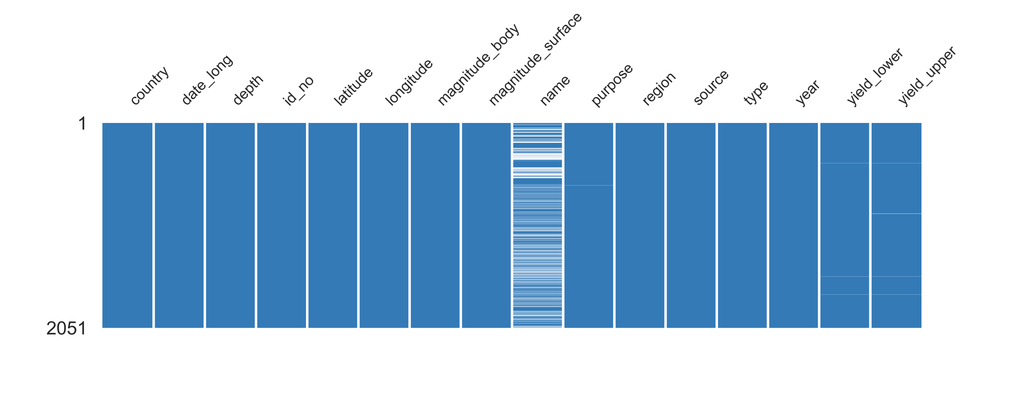

**Heatmap**

[figure not shown]

**Dendrogram**

[figure not shown]

# Sample

## First rows

|  | country | date_long | depth | id_no | latitude | longitude | magnitude_body | magnitude_surface | name | purpose | region | source | type | year | yield_lower | yield_upper |
| --- | --- | --- | --- | --- | --- | --- | --- | --- | --- | --- | --- | --- | --- | --- | --- | --- |
| 0 | USA | 19450716 | -0.10 | 45001 | 32.54 | -105.57 | 0.0 | 0.0 | TRINITY | WR | ALAMOGORDO | DOE | TOWER | 1945 | 21.0 | 21.0 |
| 1 | USA | 19450805 | -0.60 | 45002 | 34.23 | 132.27 | 0.0 | 0.0 | LITTLEBOY | COMBAT | HIROSHIMA | DOE | AIRDROP | 1945 | 15.0 | 15.0 |
| 2 | USA | 19450809 | -0.60 | 45003 | 32.45 | 129.52 | 0.0 | 0.0 | FATMAN | COMBAT | NAGASAKI | DOE | AIRDROP | 1945 | 21.0 | 21.0 |
| 3 | USA | 19460630 | -0.20 | 46001 | 11.35 | 165.20 | 0.0 | 0.0 | ABLE | WE | BIKINI | DOE | AIRDROP | 1946 | 21.0 | 21.0 |
| 4 | USA | 19460724 | 0.03 | 46002 | 11.35 | 165.20 | 0.0 | 0.0 | BAKER | WE | BIKINI | DOE | UW | 1946 | 21.0 | 21.0 |
| 5 | USA | 19480414 | -0.08 | 48001 | 11.30 | 162.15 | 0.0 | 0.0 | X-RAY | WR | ENEWETAK | DOE | TOWER | 1948 | 37.0 | 37.0 |
| 6 | USA | 19480430 | -0.08 | 48002 | 11.30 | 162.15 | 0.0 | 0.0 | YOKE | WR | ENEWETAK | DOE | TOWER | 1948 | 49.0 | 49.0 |
| 7 | USA | 19480514 | -0.08 | 48003 | 11.30 | 162.15 | 0.0 | 0.0 | ZEBRA | WR | ENEWETAK | DOE | TOWER | 1948 | 18.0 | 18.0 |
| 8 | USSR | 19490829 | 0.00 | 49001 | 48.00 | 76.00 | 0.0 | 0.0 | NaN | WR | SEMI KAZAKH | DOE | SURFACE | 1949 | 22.0 | 22.0 |
| 9 | USA | 19510127 | -0.35 | 51001 | 37.00 | -116.00 | 0.0 | 0.0 | ABLE | WR | NTS | DOE | AIRDROP | 1951 | 1.0 | 1.0 |

## Last rows

|  | country | date_long | depth | id_no | latitude | longitude | magnitude_body | magnitude_surface | name | purpose | region | source | type | year | yield_lower | yield_upper |
| --- | --- | --- | --- | --- | --- | --- | --- | --- | --- | --- | --- | --- | --- | --- | --- | --- |
| 2041 | FRANCE | 19951027 | 0.0 | 95005 | -21.891 | -138.983 | 0.0 | 0.0 | AEPYTOS | WR | MURUROA | WTN | UG | 1995 | 0.0 | 60.0 |
| 2042 | FRANCE | 19951121 | 0.0 | 95006 | -21.879 | -139.032 | 0.0 | 0.0 | PBEGEE | WR | MURUROA | WTN | UG | 1995 | 0.0 | 40.0 |
| 2043 | FRANCE | 19951227 | 0.0 | 95007 | -21.881 | -138.973 | 0.0 | 0.0 | THEMISTO | WR | MURUROA | WTN | UG | 1995 | 0.0 | 30.0 |
| 2044 | FRANCE | 19960127 | 0.0 | 96001 | -22.236 | -138.815 | 0.0 | 0.0 | XOUTHOS | WR | FANGATAUFA | WTN | UG | 1996 | 0.0 | 120.0 |
| 2045 | CHINA | 19960608 | 0.0 | 96002 | 41.650 | 88.760 | 6.3 | 0.0 | NaN | WR | LOP NOR | HFS | UG | 1996 | 30.0 | 120.0 |
| 2046 | CHINA | 19960729 | 0.0 | 96003 | 41.690 | 88.350 | 5.3 | 0.0 | NaN | WR | LOP NOR | HFS | UG | 1996 | 3.0 | 12.0 |
| 2047 | INDIA | 19980511 | 0.0 | 98001 | 27.070 | 71.700 | 5.3 | 0.0 | SHAKTI 1-3 | WR | POKHRAN | HFS | UG | 1998 | 0.0 | 20.0 |
| 2048 | INDIA | 19980513 | 0.0 | 98003 | 27.070 | 71.700 | 0.0 | 0.0 | NaN | WR | POKHRAN | NRD | UG | 1998 | 0.0 | 1.0 |
| 2049 | PAKIST | 19980528 | 0.0 | 98004 | 28.900 | 64.890 | 0.0 | 0.0 | NaN | WR | CHAGAI | HFS | UG | 1998 | 0.0 | 35.0 |
| 2050 | PAKIST | 19980530 | 0.0 | 98005 | 28.490 | 63.780 | 5.0 | 0.0 | NaN | WR | KHARAN | HFS | UG | 1998 | 0.0 | 18.0 |